# R Notebook

#Q1 Load the data.

```r
library(tidyverse)
library(janitor)
library(gtools)
```

```r
library(readr)
X20190928_items <- read_csv("data/20190928-items.csv")
View(X20190928_items)
```

```r
phone_data <-(X20190928_items)
```

```r
phone_data %>%
  select(brand)
```

| brand |
| --- |
| Nokia |
| Motorola |
| Motorola |
| Nokia |
| Motorola |
| Motorola |
| Sony |
| Nokia |
| Nokia |
| Samsung |

[output cut: 782 more lines]

```r
NA
```

```r
phone_data%>%
  count(brand)
```

| brand | n |
| --- | --- |
| Apple | 101 |
| ASUS | 13 |
| Google | 33 |
| HUAWEI | 36 |
| Motorola | 100 |
| Nokia | 49 |
| OnePlus | 7 |
| Samsung | 397 |
| Sony | 29 |
| Xiaomi | 27 |

```r
NA
```

#count and then need this is desc order.

```r
phone_data%>%
  count(brand)%>%
  arrange(desc(n))
```

| brand | n |
| --- | --- |
| Samsung | 397 |
| Apple | 101 |
| Motorola | 100 |
| Nokia | 49 |
| HUAWEI | 36 |
| Google | 33 |
| Sony | 29 |
| Xiaomi | 27 |
| ASUS | 13 |
| OnePlus | 7 |

#Q2The brand with the highest numbers of phones in the dataset is samsung with 397 phones.

```r
samsung_data <- phone_data%>%
  filter(brand == "Samsung")
```

Q3For your top brand, plot the distribution of phone ratings as a probability density, overlaying a fitted normal distribution. Do you think the normal distribution provides a good model of these ratings? #Probability density was the action

```r
review_frequency <-samsung_data %>%
  tabyl(totalReviews)
```

[output not shown]

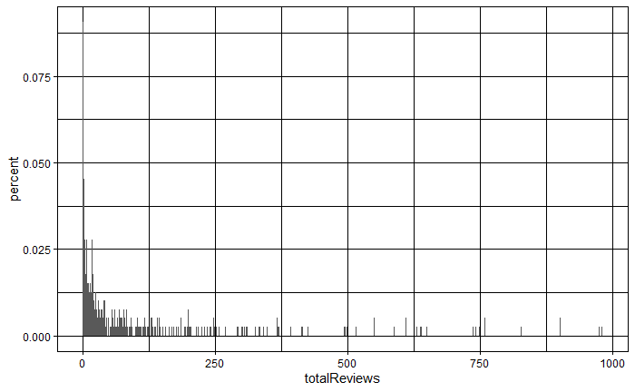

```r
review_frequency %>%
  ggplot(aes(x=totalReviews, y=percent))+
  geom_col()+
  theme_linedraw()
```

#Need to look at summarise of the distribution as this is not that great a graph. #need the mean/median/mode

```r
get_mode <- function(data){

  tabled_data <- table(data)
  table_names <- names(tabled_data)

  return( table_names[tabled_data == max(tabled_data)] )

}
```

```r
review_frequency%>%
  summarise(mean_daily_reviews = mean(totalReviews),
            median_daily_reviews = median(totalReviews),
            mode_daily_reviews = get_mode(totalReviews))
```

| mean_daily_reviews | median_daily_reviews | mode_daily_reviews |
| --- | --- | --- |
| 189.4545 | 116.5 | 1 |
| 189.4545 | 116.5 | 2 |
| 189.4545 | 116.5 | 3 |
| 189.4545 | 116.5 | 4 |
| 189.4545 | 116.5 | 5 |
| 189.4545 | 116.5 | 6 |
| 189.4545 | 116.5 | 7 |
| 189.4545 | 116.5 | 8 |
| 189.4545 | 116.5 | 9 |
| 189.4545 | 116.5 | 10 |

[output cut: 166 more lines]

```r
NA
```

#distribution shape might look better - as this looks wild.

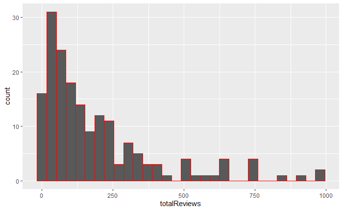

```r
review_frequency %>%
  ggplot(aes(x=totalReviews))+
  geom_histogram(col = "red")
```

```r
NA
```

#Range Refresh

```r
range_reviews <-review_frequency %>%
  summarise(range_reviews = range(totalReviews))
```

1 - 980 #outliers - ???

#Quartile and interquartile

```r
review_frequency%>%
  group_by(totalReviews)
```

| totalReviews | n | percent |
| --- | --- | --- |
| 1 | 36 | 0.090680101 |
| 2 | 18 | 0.045340050 |
| 3 | 10 | 0.025188917 |
| 4 | 10 | 0.025188917 |
| 5 | 11 | 0.027707809 |
| 6 | 7 | 0.017632242 |
| 7 | 11 | 0.027707809 |
| 8 | 4 | 0.010075567 |
| 9 | 6 | 0.015113350 |
| 10 | 6 | 0.015113350 |

[output cut: 166 more lines]

```r
NA
```

```r
review_frequency %>%
  summarise(
    num = n(),
    mean = mean(totalReviews),
    sd = sd(totalReviews)
  )
```

| num | mean | sd |
| --- | --- | --- |
| 176 | 189.4545 | 206.4855 |

```r
NA
```

#code provides the mean and the sd = standard normal that can then be plotted.

```r
samsung_data <- phone_data %>%
  filter(brand == "Samsung") %>%
  select(rating)

samsung_stats <- phone_data %>%
  filter(brand == "Samsung") %>%
  summarise(
    count = n(),
    mean = mean(rating),
    sd = sd(rating)
  )
samsung_stats
```

| count | mean | sd |
| --- | --- | --- |
| 397 | 3.5733 | 0.6847859 |

```r
NA
```

# From 397 ratings there is on average a review of 3.5733 and deviation of 0.68 deviation from the average.

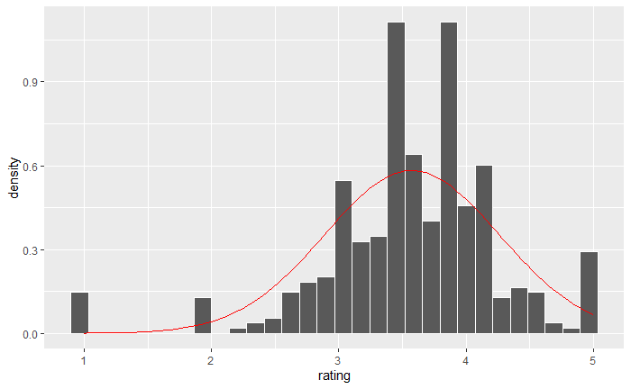

```r
samsung_data %>%
  ggplot(aes(x = rating)) +
  geom_histogram(aes(y = ..density..), col = "white") +
  stat_function(
    fun = dnorm,
    args = list(
      mean = samsung_stats$mean,
      sd = samsung_stats$sd
    ),
    col = "red"
  )
```